# Relatorio

Maxxi Lorenzzo Santos Rios, 472722

Alysson da Silva Moura, 400660

Leonardo Gomes Prado, 472920

Luis Fernando A. Brito, 418824

05/02/2022

## Incluindo os pacotes

Primeiro nós precisamos incluir o pacote `glmnet` que utilizaremos para estimar utilizando os métodos de *shrinkage*

## Questões

Primeiro vamos carregar e guardar os nossos dados na variável `dados`:

```r
dados <- read.csv("house_data_exer_tnkc_wobasement.csv")

head(dados)
```

|  | ï..price | bedrooms | bathrooms | sqft_living | sqft_lot | floors | waterfront | view | condition | grade | sqft_above | yr_built |
| --- | --- | --- | --- | --- | --- | --- | --- | --- | --- | --- | --- | --- |
| 1 | 364000 | 4 | 1.75 | 2010 | 8625 | 1 | 0 | 0 | 4 | 7 | 1340 | 1957 |
| 2 | 875000 | 5 | 3.25 | 4230 | 21455 | 2 | 0 | 0 | 3 | 10 | 2720 | 1990 |
| 3 | 1406890 | 5 | 2.25 | 3580 | 16789 | 2 | 0 | 0 | 5 | 9 | 3580 | 1966 |
| 4 | 550000 | 3 | 1.75 | 1410 | 5000 | 1 | 0 | 0 | 4 | 7 | 810 | 1923 |
| 5 | 1240000 | 5 | 4.00 | 4410 | 14380 | 2 | 0 | 0 | 3 | 11 | 4410 | 2006 |
| 6 | 326100 | 2 | 1.00 | 880 | 7683 | 1 | 0 | 0 | 3 | 6 | 880 | 1942 |

Para facilitar nossa vida, vamos renomear a primeira coluna, para `price`

```r
names(dados)[1] <- "price"
```

Pra garantir que o nosso *number generator* seja igual ao da questão, vamos utilizar o comando `base::set.seed()`

```r
set.seed(1234)
```

Agora vamos separar nossa base em *treino* e *teste*

```r
## separamos os dados entre treino e teste para evitar overfitting
index <- sample(nrow(dados),nrow(dados)*0.80)
dados.train <- dados[index,]
dados.test <- dados[-index,]


index_y <- which(colnames(dados)=="price")

#Como o pacote `gmlnet` não aceita dataframes, precisamos converter
#os dados para matrix
X.train <- as.matrix(dados.train[,-index_y])
Y.train <- as.matrix(dados.train[,index_y])

X.test <- as.matrix(dados.test[,-index_y])
Y.test <- as.matrix(dados.test[,index_y])
```

# Primeira Questão

Estime modelo de previsão usando MQO

Para estimar o modelo de Mínimo Quadrados Ordinários (MQO), precisamos utilizar a função `lm`, com os nossos dados de treino, e utilizar o Erro Quadratico Médio (*MSE*) para verificar qual estimador é mais preciso/acurado.

```r
#Treina o modelo
MQO.fit <- lm(Y.train~X.train)

MQO.fit.coef <-  as.matrix(MQO.fit$coefficients)

#É adicionado 1 na primeira coluna para multiplicar pelo \beta_{0}
X.test_1 <- cbind(1,X.test)

#Preve o modelo no dataset de teste
Y_pred.MQO <- X.test_1 %*% MQO.fit.coef

MSE_MQO <- mean((Y.test-Y_pred.MQO)^2)
```

# Segunda Questão

Estime modelo de previsão usando Ridge

Para o modelo Ridge temos que minimizar a seguinte função: $L_{ridge}(\hat\beta) = {\sum_{i =1}^{n} (y_{i} - x'_{i}\hat\beta)^{2} + \lambda\sum_{i =1}^{m}\hat\beta_{j}^{2}}$

onde $\lambda$ é o parâmetro de penalização.

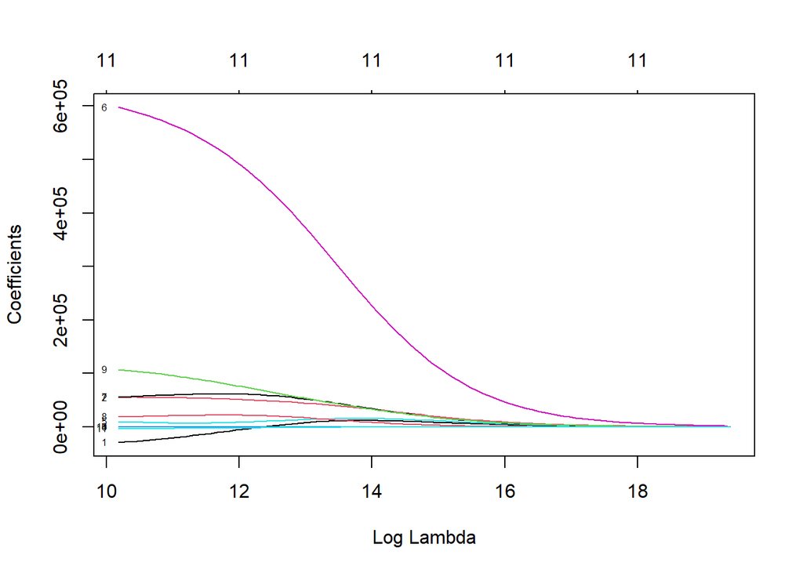

```r
#treinamos o modelo com o dataset de treino
ridge.fit <- glmnet(x = X.train, y = Y.train, family = "gaussian", alpha = 0)

plot(ridge.fit, xvar="lambda", label=TRUE)
```

Agora nós utilizamos a técnica de *cross validation* para escolher o $\lambda$ que minimiza a Soma dos Quadrados dos Resíduos (*SSR*):

- separar os dados de teste em $k$ partes (geralmente 10) ou *folds*
- treinar o modelo em $k - 1$ partes ou *folds*
- validar o modelo na parte que restou dos dados

a performace do modelo é dada pela média dos valores computados no algorítimo.

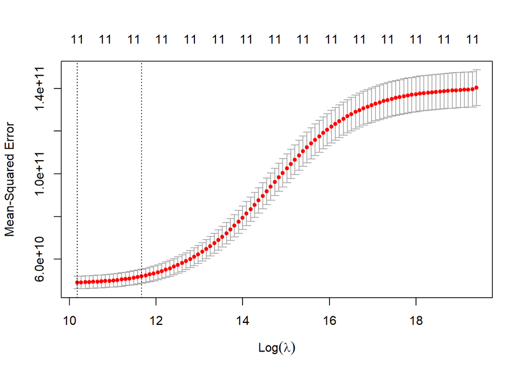

```r
cv.ridge <-  cv.glmnet(x=X.train, y=Y.train, family="gaussian", alpha=0, nfolds=10)

plot(cv.ridge)
```

então como fizemos no `lm`, nós utilizamos o modelo treinado para prever os dados de teste, e computamos novamente o *MSE*

```r
coef(cv.ridge, s=cv.ridge$lambda.min)
```

```
## 12 x 1 sparse Matrix of class "dgCMatrix"
##                        s1
## (Intercept)  5.632635e+06
## bedrooms    -2.923906e+04
## bathrooms    5.515037e+04
## sqft_living  1.348429e+02
## sqft_lot    -3.115405e-01
## floors       9.870331e+03
## waterfront   5.978205e+05
## view         5.576025e+04
## condition    1.878419e+04
## grade        1.069491e+05
## sqft_above   4.388595e+01
## yr_built    -3.237182e+03
```

```r
Y_pred.ridge <- predict(ridge.fit, newx = X.test, s=cv.ridge$lambda.min)

MSE_ridge <- mean((Y.test-Y_pred.ridge)^2)
```

# Terceira Questão

Estime modelo de previsão usando Lasso

Para o LASSO, estimamos a seguinte *loss function*: $L_{ridge}(\hat\beta) = {\sum_{i =1}^{n} (y_{i} - x'_{i}\hat\beta)^{2} + \lambda\sum_{i =1}^{m}|\hat\beta_{j}^{2}}|$

e seguimos os mesmos passos do *ridge*:

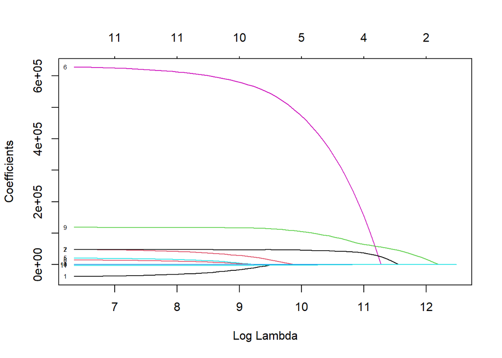

```r
lasso.fit <- glmnet(x=X.train, y=Y.train, family="gaussian", alpha=1)

plot(lasso.fit,xvar="lambda", label=TRUE)
```

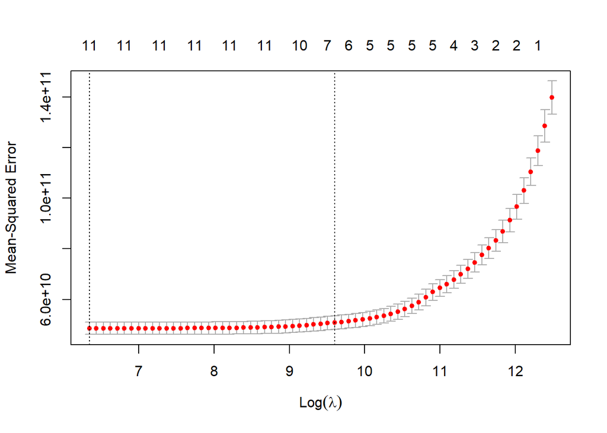

```r
cv.lasso <- cv.glmnet(x=X.train, y=Y.train,family="gaussian", alpha=1, nfolds=10)

plot(cv.lasso)
```

```r
coef(cv.lasso, s=cv.lasso$lambda.min)
```

```
## 12 x 1 sparse Matrix of class "dgCMatrix"
##                        s1
## (Intercept)  6.312515e+06
## bedrooms    -3.809605e+04
## bathrooms    4.779281e+04
## sqft_living  1.738462e+02
## sqft_lot    -3.352519e-01
## floors       2.021025e+04
## waterfront   6.284264e+05
## view         4.767077e+04
## condition    1.428417e+04
## grade        1.182044e+05
## sqft_above   8.438847e+00
## yr_built    -3.610792e+03
```

```r
Y_pred.lasso <- predict(lasso.fit, newx = X.test, s=cv.lasso$lambda.min)

MSE_lasso <- mean((Y.test-Y_pred.lasso)^2)
```

# Qual o melhor modelo? Justifique.

Para identificarmos o melhor modelo basta compararmos o *MSE* de cada um, o que possui menor EQM é o melhor estimador. Sendo assim:

```r
EQM <- cbind("EQM" = c(MSE_MQO, MSE_ridge, MSE_lasso))
rownames(EQM) <- c("MQO", "Ridge", "LASSO")

EQM
```

```
##               EQM
## MQO   50080062379
## Ridge 50692792013
## LASSO 50034086885
```

Nesse sentido, o LASSO seria o nosso melhor estimador.

### Questão Extra

Ponto extra: Estime modelo de previsão usando Elastic-net (com alpha={ 0.25;0.5;0.75}). Compare com modelos anteriores.

Primeiro vamos criar uma função para calcular o Elastic-net com vários alphas:

```r
estimadorElasticNet <- function(x_treino, y_treino, x_teste, y_teste, alpha, folds = 10) {

  elastic.fit <- glmnet::glmnet(x=X.train, y=Y.train,family="gaussian",alpha=alpha)

  cv.elastic <- glmnet::cv.glmnet(x = X.train, y = Y.train, family = "gaussian", alpha = alpha, nfolds=folds)

  coefElastic <- broom::tidy(coef(cv.elastic, s = cv.elastic$lambda.min))


  Y_pred.elastic <- predict(elastic.fit, newx = X.test, s = cv.elastic$lambda.min)

  MSE_elastic <- mean(( Y.test-Y_pred.elastic)^2 )

  elasticTibble <- tibble::tibble(
    coeficientes = list(coefElastic),
    cv = list(cv.elastic),
    MSE = MSE_elastic
  )

  }
```

Enfim nós rodamos para os alphas desejados:

```r
alphas <- c(.25, .5, .75)

elasticAlphas <- purrr::map_df(alphas,  ~estimadorElasticNet(x_treino = X.train, y_treino = Y.train, x_teste = X.test, y_teste = Y.test, alpha = .x) %>% cbind(alpha = .x))
```

Como fizemos anteriormente podemos selecionar o melhor modelo com base no EQM. Assim:

```r
MSE_elastic <- elasticAlphas %>% select(MSE, alpha)

MSE_elastic %>% knitr::kable(., format="html")
```

| MSE | alpha |
| --- | --- |
| 50075379162 | 0.25 |
| 50052709530 | 0.50 |
| 50042897931 | 0.75 |

E comparando com os outros:

```r
EQMTotal <- cbind("EQM" = c(MSE_MQO, MSE_ridge, MSE_lasso, MSE_elastic$MSE))
rownames(EQMTotal) <- c("MQO", "Ridge", "LASSO", "ELASTIC(0.25)", "ELASTIC(0.50)", "ELASTIC(0.75)")

print(EQMTotal)
```

```
##                       EQM
## MQO           50080062379
## Ridge         50692792013
## LASSO         50034086885
## ELASTIC(0.25) 50075379162
## ELASTIC(0.50) 50052709530
## ELASTIC(0.75) 50042897931
```